# Regression Analysis and Diagnostic Tests

Lumumba W. Victor

2026-08-18

# **Regression and Correlational Analysis in R**

## **Regression Analysis**

Regression analysis is a statistical technique used to examine the relationship between one or more independent variables (predictors) and a dependent variable (outcome). It helps to understand how changes in the independent variables are associated with changes in the dependent variable. Regression analysis can be used for prediction, forecasting, and identifying important factors that influence the outcome.

## **History of Regression Analysis**

Regression analysis has a long history dating back to the 19th century. The term “regression” was first introduced by Sir Francis Galton in the late 1800s when he observed that the heights of children tended to regress toward the mean height of their parents. This concept laid the foundation for the development of regression analysis as a statistical method.

Karl Pearson and Ronald Fisher further contributed to the development of regression techniques in the early 20th century, leading to the widespread use of regression analysis in various fields such as economics, social sciences, and natural sciences.

## **Correlation Analysis**

Correlation analysis, on the other hand, is a statistical method used to measure the strength and direction of the relationship between two variables. It quantifies the degree to which changes in one variable are associated with changes in another variable. Correlation analysis does not imply causation; it only indicates the presence and strength of a relationship.

## **Distinguishing Correlation and Causation**

The two concepts of correlation and causation are often confused, but they are distinct. Correlation indicates a statistical association between two variables, while causation implies that changes in one variable directly cause changes in another. It is important to note that correlation does not imply causation, and further research is often needed to establish causal relationships.

## **Set up the Current Working Directory**

```r
setwd("D:/Research Workshop and Seminars and Trainings/MEDIACREST COLLEGE/Advanced Data Analysis and AI-August Intake/Week-2-Sessions")
```

### **Explore the Data set**

```r
# Load data
data(mtcars)
head(mtcars)
```

```
                   mpg cyl disp  hp drat    wt  qsec vs am gear carb
Mazda RX4         21.0   6  160 110 3.90 2.620 16.46  0  1    4    4
Mazda RX4 Wag     21.0   6  160 110 3.90 2.875 17.02  0  1    4    4
Datsun 710        22.8   4  108  93 3.85 2.320 18.61  1  1    4    1
Hornet 4 Drive    21.4   6  258 110 3.08 3.215 19.44  1  0    3    1
Hornet Sportabout 18.7   8  360 175 3.15 3.440 17.02  0  0    3    2
Valiant           18.1   6  225 105 2.76 3.460 20.22  1  0    3    1
```

```r
# View structure
str(mtcars)
```

```
'data.frame':   32 obs. of  11 variables:
 $ mpg : num  21 21 22.8 21.4 18.7 18.1 14.3 24.4 22.8 19.2 ...
 $ cyl : num  6 6 4 6 8 6 8 4 4 6 ...
 $ disp: num  160 160 108 258 360 ...
 $ hp  : num  110 110 93 110 175 105 245 62 95 123 ...
 $ drat: num  3.9 3.9 3.85 3.08 3.15 2.76 3.21 3.69 3.92 3.92 ...
 $ wt  : num  2.62 2.88 2.32 3.21 3.44 ...
 $ qsec: num  16.5 17 18.6 19.4 17 ...
 $ vs  : num  0 0 1 1 0 1 0 1 1 1 ...
 $ am  : num  1 1 1 0 0 0 0 0 0 0 ...
 $ gear: num  4 4 4 3 3 3 3 4 4 4 ...
 $ carb: num  4 4 1 1 2 1 4 2 2 4 ...
```

### **Description of the Dataset**

mtcars {datasets} R Documentation Motor Trend Car Road Tests

**Description**

The data was extracted from the 1974 Motor Trend US magazine, and comprises fuel consumption and 10 aspects of automobile design and performance for 32 automobiles (1973–74 models).

Usage mtcars Format A data frame with 32 observations on 11 (numeric) variables.

## **Scatter Plots are Essential Before Regression and Correlation**

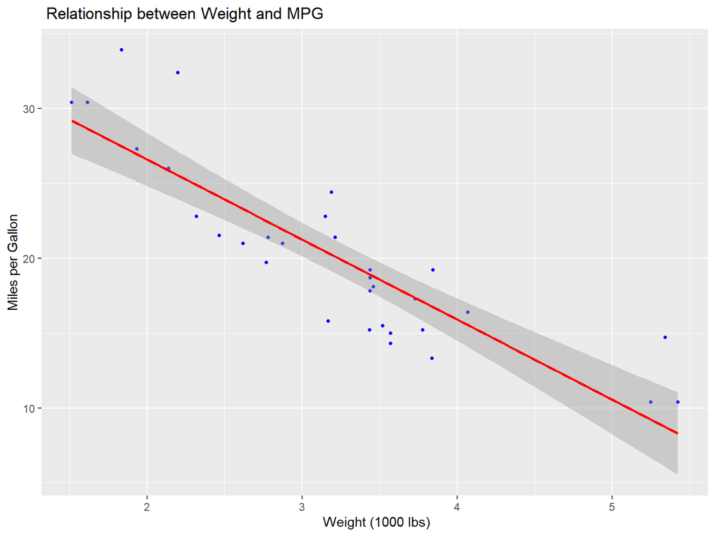

```r
library ( ggplot2 )

# Scatterplot : Weight vs MPG
ggplot(mtcars, aes(x=wt, y=mpg)) +
  geom_point( color ="blue", size =1) +
  geom_smooth( method ="lm", se=TRUE, color ="red") +
  labs (title =" Relationship between Weight and MPG",
         x=" Weight (1000 lbs)", y=" Miles per Gallon ")
```

** NOte** There is a strong negative correlation between weight and miles per gallon. As the weight of the car increases, the miles per gallon decreases.

## **Comput Pearson Correlation Analysis in R**

```r
# Compute Pearson correlation
cor(mtcars$wt, mtcars$mpg, method = "pearson")
```

```
[1] -0.8676594
```

### **State the null and alternative hypotheses:**

- H0: There is no significant correlation between weight and miles per gallon (r = 0).
- H1: There is a significant correlation between weight and miles per gallon (r ≠ 0).

### **Decision Rule:**

- If the p-value is less than the significance level (commonly set at 0.05), we reject the null hypothesis. Otherwise, we fail to reject the null hypothesis.

### **Testing the Significance of the Correlation**

```r
cor.test(mtcars$wt, mtcars$mpg, method = "pearson")
```

```
    Pearson's product-moment correlation

data:  mtcars$wt and mtcars$mpg
t = -9.559, df = 30, p-value = 1.294e-10
alternative hypothesis: true correlation is not equal to 0
95 percent confidence interval:
 -0.9338264 -0.7440872
sample estimates:
       cor
-0.8676594
```

**Interpretation:** The Pearson correlation coefficient (r) is -0.867, indicating a strong negative correlation between weight and miles per gallon. The p-value is less than 0.05, which means we reject the null hypothesis and conclude that there is a statistically significant correlation between weight and miles per gallon.

### **When Normality is Violated or Data is Ordinal**

```r
# Compute Spearman correlation
cor(mtcars$wt, mtcars $mpg, method = "spearman")
```

```
[1] -0.886422
```

```r
# Test significance
cor.test(mtcars$wt, mtcars$mpg, method = "spearman")
```

```
    Spearman's rank correlation rho

data:  mtcars$wt and mtcars$mpg
S = 10292, p-value = 1.488e-11
alternative hypothesis: true rho is not equal to 0
sample estimates:
      rho
-0.886422
```

### **Examine relationships between multiple variables simultaneously.**

```r
# Select numeric columns
num_vars <- mtcars[, c("mpg", "cyl", "disp", "hp", "wt")]

# Correlation matrix
cor_matrix <- cor(num_vars, method = "pearson")
print(round(cor_matrix, 2))
```

```
       mpg   cyl  disp    hp    wt
mpg   1.00 -0.85 -0.85 -0.78 -0.87
cyl  -0.85  1.00  0.90  0.83  0.78
disp -0.85  0.90  1.00  0.79  0.89
hp   -0.78  0.83  0.79  1.00  0.66
wt   -0.87  0.78  0.89  0.66  1.00
```

```r
# Select numeric columns
num_vars <- mtcars[, c("mpg", "cyl", "disp", "hp", "wt")]

# Correlation matrix
cov_matrix <- cov(num_vars, method = "pearson")
print(round(cov_matrix, 2))
```

```
         mpg    cyl     disp      hp     wt
mpg    36.32  -9.17  -633.10 -320.73  -5.12
cyl    -9.17   3.19   199.66  101.93   1.37
disp -633.10 199.66 15360.80 6721.16 107.68
hp   -320.73 101.93  6721.16 4700.87  44.19
wt     -5.12   1.37   107.68   44.19   0.96
```

### **Visualize Correlation Matrix**

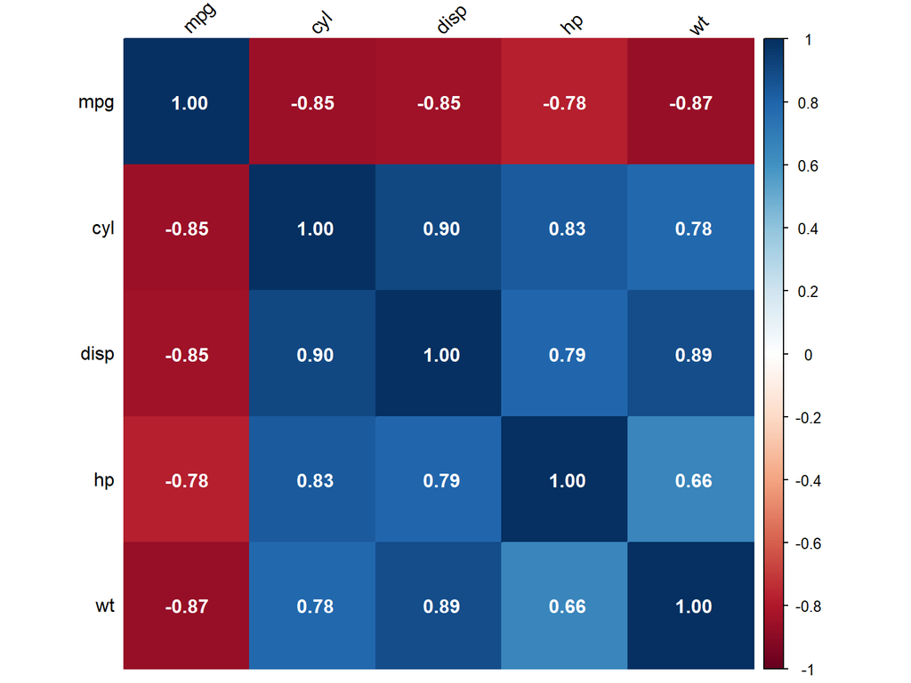

```r
library(corrplot)
corrplot(cor_matrix,
         #title = "Pairwise Correlation Plot",
         method = "color",
         #type = "upper",
         addCoef.col = "white",
         tl.col = "black",
         tl.srt = 45)
```

### **SLR Model in R**

```r
## Fit Simple Linear Regression
model_slr <- lm(mpg ~ wt, data = mtcars )
```

```r
summary(model_slr)
```

```
Call:
lm(formula = mpg ~ wt, data = mtcars)

Residuals:
    Min      1Q  Median      3Q     Max
-4.5432 -2.3647 -0.1252  1.4096  6.8727

Coefficients:
            Estimate Std. Error t value Pr(>|t|)
(Intercept)  37.2851     1.8776  19.858  < 2e-16 ***
wt           -5.3445     0.5591  -9.559 1.29e-10 ***
---
Signif. codes:  0 '***' 0.001 '**' 0.01 '*' 0.05 '.' 0.1 ' ' 1

Residual standard error: 3.046 on 30 degrees of freedom
Multiple R-squared:  0.7528,    Adjusted R-squared:  0.7446
F-statistic: 91.38 on 1 and 30 DF,  p-value: 1.294e-10
```

### **State the Null and Alternative Hypotheses:**

- H0: There is no statistically significant effect of weight of the car on miles per gallon (the coefficient for weight is equal to zero) at 5% level of significance.
- H1: There is a statistically significant effect of weight of the car on miles per gallon (the coefficient for weight is not equal to zero) at 5% level of significance.

### **Simple Linear Regression Equation**

$$\text{Equation:} = \hat{MPG} = 37.2851
-5.3445 \times \text{wt}$$

**Interpretation:** The coefficient for weight (wt) is -5.344, which means that for every 1 unit increase in weight (1000 lbs), the miles per gallon (mpg) decreases by approximately 5.344 units, holding all else constant. The p-value for the weight variable is less than 0.05, indicating that the effect of weight on miles per gallon is statistically significant at 5% level of significance.

### **Null and Alternative Hypotheses for the Overall Model (F-Test):**

- H0: The overall regression model is not statistically significant (the model does not explain a significant portion of the variance in miles per gallon).
- H1: The overall regression model is statistically significant (the model explains a significant portion of the variance in miles per gallon).

### **Decision Rule:**

- If the p-value for the F-test is less than the significance level (commonly set at 0.05), we reject the null hypothesis. Otherwise, we fail to reject the null hypothesis.

**Interpretation of F-Test:** The F-statistic is 91.38 with a p-value of 1.294e-10, which is less than 0.05. Therefore, we reject the null hypothesis and conclude that the overall regression model is statistically significant, meaning that weight of the car significantly explains the variance in miles per gallon.

### **Report R-squared and Adjusted R-squared:**

- R-squared: 0.7528
- Adjusted R-squared: 0.7446 **Interpretation:**

The R-squared value of 0.7528 indicates that approximately 75.28% of the variance in miles per gallon (mpg) can be explained by the weight of the car (wt). The adjusted R-squared value of 0.7446 accounts for the number of predictors in the model and provides a more accurate measure of the model’s explanatory power. In this case the adjusted R-squared is slightly lower than the R-squared, which suggests that the model is a good fit for the data, but there may be some room for improvement by including additional predictors.

### **Confidence Intervals for the Coefficients:**

```r
confint(model_slr, level = 0.95)
```

```
                2.5 %    97.5 %
(Intercept) 33.450500 41.119753
wt          -6.486308 -4.202635
```

**Interpretation:** The 95% confidence interval for the intercept (37.2851) ranges from 33.45 to 41.12, which means we are 95% confident that the true intercept value lies within this range. The 95% confidence interval for the weight coefficient (-5.3445) ranges from -6.49 to -4.20, which means we are 95% confident that the true effect of weight on miles per gallon lies within this range. Since the confidence interval for the weight coefficient does not include zero, it further supports the conclusion that weight has a statistically significant effect on miles per gallon at the 5% level of significance.

### **Prediction Using the SLR Model:**

```r
# New data frame
new_car <- data.frame(wt = 3.5)
new_car
```

```
   wt
1 3.5
```

### **Narrow confidence interval for the mean response**

```r
# Predict with Confidence Interval
predict(model_slr, newdata = new_car,
         interval = "confidence")
```

```
       fit      lwr      upr
1 18.57948 17.43342 19.72553
```

```r
# Predict with Prediction Interval ( wider )
predict(model_slr, newdata = new_car ,
        interval = "prediction")
```

```
       fit      lwr      upr
1 18.57948 12.25426 24.90469
```

## **Using Hypertension Data Set to Develop SLR**

```r
# Load data
htn <- read.csv("htn_dat.csv")
head(htn)
```

```
     ID DBP SBP      BMI      age married male.gender hgb_centered adv_HIV
1 16097  60  90       NA 28.00000       0           0           NA      NA
2   930  75 110 27.33991 26.45859       1           0   -3.8999996       0
3  6877  60  80 17.68979 42.95140       0           0   -3.1999998      NA
4 36464  60  90 19.85408 50.14921       1           1           NA      NA
5 36180  60 100 21.29529 30.55441       0           1   -0.3999996      NA
6  7923  60 120 16.88019 20.37235       1           0   -4.0000000      NA
  survtime event arv_naive urban.clinic log_creat_centered IPW_weight SBP_ge120
1      338     1         1            0                 NA  0.9243794         0
2      439     1         1            1          0.0542177  1.1638615         0
3      752     1         1            0         -0.3597409  0.7211478         0
4      526     1         1            1                 NA  0.8294520         0
5      215     1         1            0         -0.0000001  0.8560456         0
6      272     1         1            0          0.3344296  1.1646913         0
```

### **Explore the Data

```r
## Check the Structure of the Data
str(htn)
```

```
'data.frame':   4999 obs. of  16 variables:
 $ ID                : int  16097 930 6877 36464 36180 7923 30408 40375 34243 7355 ...
 $ DBP               : int  60 75 60 60 60 60 59 60 70 58 ...
 $ SBP               : int  90 110 80 90 100 120 100 100 120 110 ...
 $ BMI               : num  NA 27.3 17.7 19.9 21.3 ...
 $ age               : num  28 26.5 43 50.1 30.6 ...
 $ married           : int  0 1 0 1 0 1 0 0 1 1 ...
 $ male.gender       : int  0 0 0 1 1 0 0 1 0 0 ...
 $ hgb_centered      : num  NA -3.9 -3.2 NA -0.4 ...
 $ adv_HIV           : int  NA 0 NA NA NA NA NA NA NA NA ...
 $ survtime          : int  338 439 752 526 215 272 1669 388 14 419 ...
 $ event             : int  1 1 1 1 1 1 1 1 1 1 ...
 $ arv_naive         : int  1 1 1 1 1 1 1 0 1 1 ...
 $ urban.clinic      : int  0 1 0 1 0 0 1 0 0 0 ...
 $ log_creat_centered: num  NA 5.42e-02 -3.60e-01 NA -1.00e-07 ...
 $ IPW_weight        : num  0.924 1.164 0.721 0.829 0.856 ...
 $ SBP_ge120         : int  0 0 0 0 0 0 0 0 0 0 ...
```

### **Check the Presence of Missing Value

```r
# Check for missing values as a dataframe
Missing_Values <- data.frame(Missing.values = colSums(is.na(htn)))
Missing_Values
```

```
                   Missing.values
ID                              0
DBP                             0
SBP                             0
BMI                           670
age                             0
married                       164
male.gender                     0
hgb_centered                 1394
adv_HIV                      1961
survtime                        0
event                           0
arv_naive                       0
urban.clinic                    0
log_creat_centered           1538
IPW_weight                      0
SBP_ge120                       0
```

### **Alternatively**

```r
# Check for missing values as a dataframe
missing_values <- data.frame(
  Variable = names(htn),
  Missing_Count = sapply(htn, function(x) sum(is.na(x))),
  Missing_Percentage = sapply(htn, function(x) mean(is.na(x)) * 100)
)
missing_values
```

```
                             Variable Missing_Count Missing_Percentage
ID                                 ID             0           0.000000
DBP                               DBP             0           0.000000
SBP                               SBP             0           0.000000
BMI                               BMI           670          13.402681
age                               age             0           0.000000
married                       married           164           3.280656
male.gender               male.gender             0           0.000000
hgb_centered             hgb_centered          1394          27.885577
adv_HIV                       adv_HIV          1961          39.227846
survtime                     survtime             0           0.000000
event                           event             0           0.000000
arv_naive                   arv_naive             0           0.000000
urban.clinic             urban.clinic             0           0.000000
log_creat_centered log_creat_centered          1538          30.766153
IPW_weight                 IPW_weight             0           0.000000
SBP_ge120                   SBP_ge120             0           0.000000
```

### **Check Distribution of BMI**

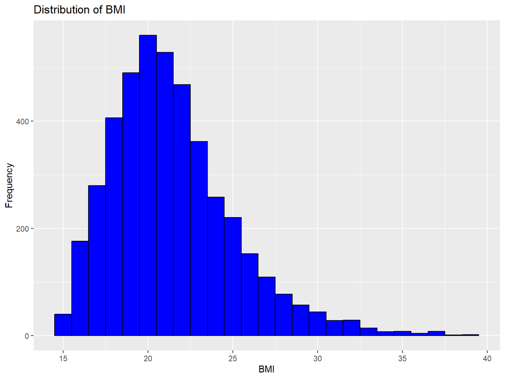

```r
ggplot(htn, aes(x = BMI)) +
  geom_histogram(binwidth = 1, fill = "blue", color = "black") +
  labs(title = "Distribution of BMI", x = "BMI", y = "Frequency")
```

### **Summmary Statistics to Check Skeweness**

```r
library(psych)
describe(htn)
```

```
                   vars    n     mean       sd   median  trimmed      mad
ID                    1 4999 24972.22 14379.94 25464.00 25026.67 18636.28
DBP                   2 4999    68.03    10.32    70.00    67.41    14.83
SBP                   3 4999   110.59    14.78   110.00   109.61    14.83
BMI                   4 4329    21.43     3.62    20.84    21.10     3.21
age                   5 4999    35.19    10.56    33.47    34.31    10.47
married               6 4835     0.59     0.49     1.00     0.61     0.00
male.gender           7 4999     0.27     0.44     0.00     0.21     0.00
hgb_centered          8 3605    -0.05     2.59     0.10    -0.01     2.37
adv_HIV               9 3038     0.63     0.48     1.00     0.66     0.00
survtime             10 4999   750.53   650.88   589.00   684.74   716.10
event                11 4999     0.15     0.36     0.00     0.06     0.00
arv_naive            12 4999     0.91     0.29     1.00     1.00     0.00
urban.clinic         13 4999     0.47     0.50     0.00     0.47     0.00
log_creat_centered   14 3461    -0.09     0.32    -0.10    -0.10     0.27
IPW_weight           15 4999     1.00     0.33     0.96     0.97     0.18
SBP_ge120            16 4999     0.05     0.22     0.00     0.00     0.00
                      min      max    range  skew kurtosis     se
ID                   6.00 49474.00 49468.00 -0.03    -1.21 203.38
DBP                 40.00   120.00    80.00  0.66     1.29   0.15
SBP                 65.00   210.00   145.00  1.13     3.71   0.21
BMI                 15.00    39.44    24.44  1.01     1.52   0.06
age                 16.02    79.63    63.61  0.81     0.56   0.15
married              0.00     1.00     1.00 -0.36    -1.87   0.01
male.gender          0.00     1.00     1.00  1.03    -0.94   0.01
hgb_centered       -10.60    35.20    45.80  1.03    14.46   0.04
adv_HIV              0.00     1.00     1.00 -0.53    -1.72   0.01
survtime             0.00  2383.00  2383.00  0.67    -0.65   9.21
event                0.00     1.00     1.00  1.96     1.84   0.01
arv_naive            0.00     1.00     1.00 -2.79     5.78   0.00
urban.clinic         0.00     1.00     1.00  0.11    -1.99   0.01
log_creat_centered  -1.83     2.32     4.15  0.49     5.11   0.01
IPW_weight           0.52     5.38     4.86  4.56    32.49   0.00
SBP_ge120            0.00     1.00     1.00  4.13    15.04   0.00
```

### **Handle Missing Values**

1. Approach 1: Remove rows with missing values (complete case analysis)

```r
comp_data <- na.omit(htn)
head(comp_data)
```

```
      ID DBP SBP      BMI      age married male.gender hgb_centered adv_HIV
2    930  75 110 27.33991 26.45859       1           0   -3.8999996       0
12 46748  60 120 23.06820 40.53114       1           1   -3.9300003       1
13 17789  53 127 21.98989 32.91992       1           0   -1.3000002       1
18 35892  70 110 20.98399 36.59685       0           1    1.1000004       0
23 35839  75 100 15.39669 42.48870       1           1   -0.8000002       1
25 45813  70 120 17.43285 37.28131       0           1   -0.6999998       1
   survtime event arv_naive urban.clinic log_creat_centered IPW_weight
2       439     1         1            1          0.0542177  1.1638615
12      914     1         1            0          0.2231434  0.8560456
13       23     1         1            1         -0.2782034  0.9165061
18      356     1         1            0          0.0136212  0.6677078
23      439     1         1            1          0.0689930  0.8294520
25      855     1         1            0         -0.1053606  0.8310089
   SBP_ge120
2          0
12         0
13         0
18         0
23         0
25         0
```

### **Check Missing Values after Cleaning**

```r
data.frame(colSums(is.na(comp_data)))
```

```
                   colSums.is.na.comp_data..
ID                                         0
DBP                                        0
SBP                                        0
BMI                                        0
age                                        0
married                                    0
male.gender                                0
hgb_centered                               0
adv_HIV                                    0
survtime                                   0
event                                      0
arv_naive                                  0
urban.clinic                               0
log_creat_centered                         0
IPW_weight                                 0
SBP_ge120                                  0
```

### **Scatter Plot to Show the Relationship between SBP and BMI**

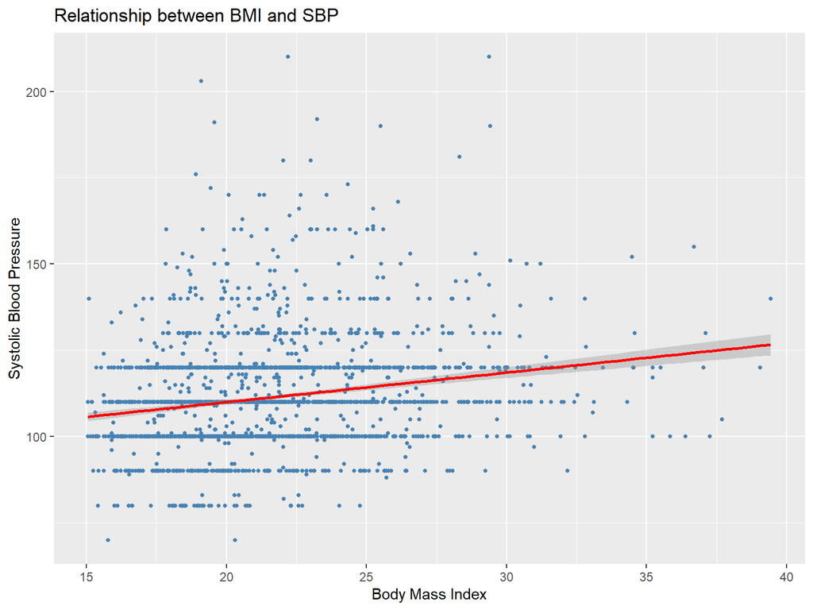

```r
ggplot(comp_data, aes(x = BMI, y = SBP)) +
  geom_point(color = "steelblue", size = 1) +
  geom_smooth(method = "lm", se = TRUE, color = "red") +
  labs(title = "Relationship between BMI and SBP",
       x = "Body Mass Index", y = "Systolic Blood Pressure")
```

### Estimate the SLR Model

```r
model_htn <- lm(SBP ~ BMI, data = comp_data, level = 0.95)
summary(model_htn)
```

```
Call:
lm(formula = SBP ~ BMI, data = comp_data, level = 0.95)

Residuals:
    Min      1Q  Median      3Q     Max
-40.253  -9.940  -0.960   8.247  98.130

Coefficients:
            Estimate Std. Error t value Pr(>|t|)
(Intercept) 92.84148    1.87229   49.59   <2e-16 ***
BMI          0.85717    0.08562   10.01   <2e-16 ***
---
Signif. codes:  0 '***' 0.001 '**' 0.01 '*' 0.05 '.' 0.1 ' ' 1

Residual standard error: 15.16 on 2324 degrees of freedom
Multiple R-squared:  0.04135,   Adjusted R-squared:  0.04093
F-statistic: 100.2 on 1 and 2324 DF,  p-value: < 2.2e-16
```

### **The Equation of the SLR Model**

$$\hat{SBP} = 92.84148 + 0.85717 \times
BMI$$

### **Ranges for BMI**

- Normal BMI: 18.5 to 24.9
- Overweight BMI: 25 to 29.9
- Obese BMI: 30 or higher

### **The BMI of the New Patient**

```r
bmi= (75)/(1.75^2)
bmi
```

```
[1] 24.4898
```

```r
new_person <- data.frame(BMI = bmi)
new_person
```

```
      BMI
1 24.4898
```

```r
# Predict SBP with Confidence Interval
predict(model_htn, newdata = new_person, interval = "confidence")
```

```
       fit      lwr      upr
1 113.8334 113.0444 114.6223
```

```r
# Predict SBP with Prediction Interval
predict(model_htn, newdata = new_person, interval = "prediction")
```

```
       fit      lwr      upr
1 113.8334 84.09181 143.5749
```

### **Multiple Linear Regression (MLR) Model**

- Predictors: wt and hp
- Outcome: mpg

### **State the Null and Alternative Hypotheses for the MLR Model:**

- H0: There is no statistically significant effect of weight and horsepower on miles per gallon (the coefficients for weight and horsepower are equal to zero) at 5% level of significance.
- H1: There is a statistically significant effect of weight and horsepower on miles per gallon (the coefficients for weight and horsepower are not equal to zero) at 5% level of significance.

### **Select of Level of Significance**

- Commonly set at 0.05

#### **Run the Test (Multple Linear Regression Model)**

```r
model_mlr <- lm(mpg ~ wt + hp, data = mtcars)
summary(model_mlr)
```

```
Call:
lm(formula = mpg ~ wt + hp, data = mtcars)

Residuals:
   Min     1Q Median     3Q    Max
-3.941 -1.600 -0.182  1.050  5.854

Coefficients:
            Estimate Std. Error t value Pr(>|t|)
(Intercept) 37.22727    1.59879  23.285  < 2e-16 ***
wt          -3.87783    0.63273  -6.129 1.12e-06 ***
hp          -0.03177    0.00903  -3.519  0.00145 **
---
Signif. codes:  0 '***' 0.001 '**' 0.01 '*' 0.05 '.' 0.1 ' ' 1

Residual standard error: 2.593 on 29 degrees of freedom
Multiple R-squared:  0.8268,    Adjusted R-squared:  0.8148
F-statistic: 69.21 on 2 and 29 DF,  p-value: 9.109e-12
```

### **The Equation of the MLR Model**

$$\hat{MPG} = 37.22727 - 3.877 \times
\text{wt} - 0.031 \times \text{hp}$$

### **Decision Rule for the MLR Model:**

> If the p-value for a predictor is less than the significance level (commonly set at 0.05), we reject the null hypothesis for that predictor. Otherwise, we fail to reject the null hypothesis for that predictor.

### **Interpretation of the MLR Model:**

- The coefficient for weight (wt) is -3.877, which means that for every 1 unit increase in weight (1000 lbs), the miles per gallon (mpg) decreases by approximately 3.877 units, holding horsepower (hp) constant. The p-value for weight is less than 0.05, indicating that the effect of weight on miles per gallon is statistically significant at 5% level of significance.
- The coefficient for horsepower (hp) is -0.031, which means that for every 1 unit increase in horsepower, the miles per gallon (mpg) decreases by approximately 0.031 units, holding weight (wt) constant. The p-value for horsepower is less than 0.05, indicating that the effect of horsepower on miles per gallon is statistically significant at 5% level of significance.

### **Reporyt R-squared and Adjusted R-squared for the MLR Model:**

- An R-squared value of 0.8268 indicates that approximately 82.68% of the variance in miles per gallon (mpg) can be explained by the weight and horsepower of the car. The adjusted R-squared value of 0.8148 accounts for the number of predictors in the model and provides a more accurate measure of the model’s explanatory power. In this case, the adjusted R-squared is slightly lower than the R-squared, which suggests that the model is a good fit for the data, but there may be some room for improvement by including additional predictors or considering interactions between predictors.
- An adjusted R-squared value of 0.8148 indicates that approximately 81.48% of the variance in miles per gallon (mpg) can be explained by the weight and horsepower of the car, after adjusting for the number of predictors in the model. This suggests that the model has a strong explanatory power, but there may still be some unexplained variance that could potentially be accounted for by including additional predictors or considering interactions between predictors.

## **Model Diagnostics for the MLR Model**

> Multicollinearity

Multicollinearity occurs when two or more predictor variables in a multiple regression model are highly correlated with each other. This can lead to unstable estimates of the regression coefficients and make it difficult to determine the individual effect of each predictor on the outcome variable.

```r
library (car)
# Calculate VIF
vif(model_mlr)
```

```
      wt       hp
1.766625 1.766625
```

### **Report VIF Values:**

- VIF values for weight (wt) and horsepower is 1.766625 indicating that there is no significant multicollinearity between the predictors in the model. Generally, a VIF value greater than 5 or 10 is considered indicative of high multicollinearity, so in this case, the VIF values suggest that multicollinearity is not a concern for this model.

### **Diagnostic Plots for the MLR Model**

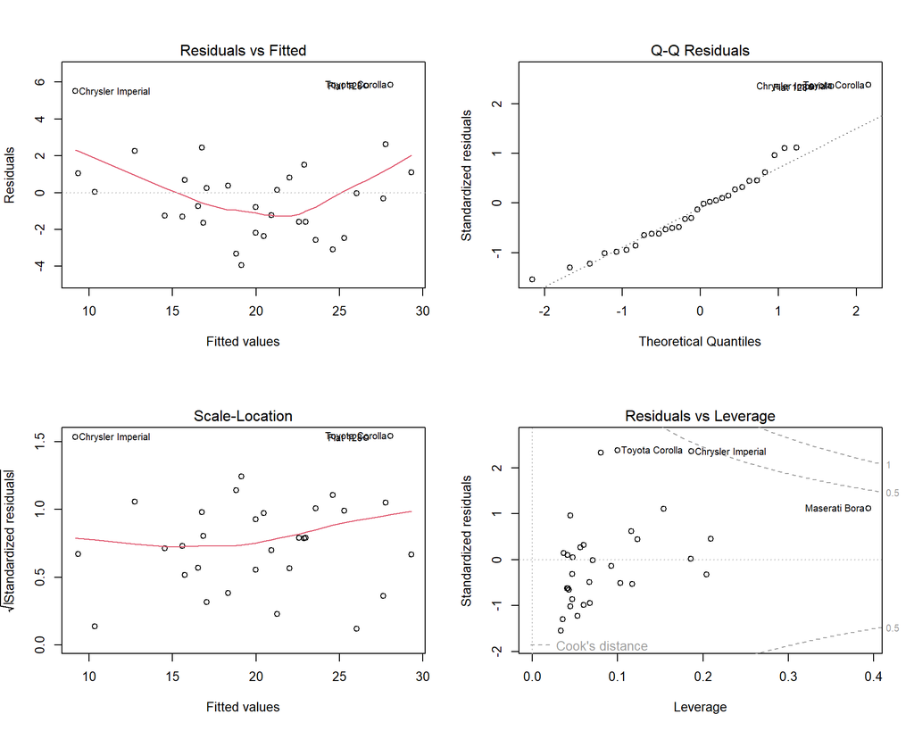

```r
# Generate diagnostic plots
par(mfrow =c(2 ,2))
plot(model_mlr)
```

```r
par(mfrow =c(1 ,1))
```

### **Identify the Influential Observation as Indicared by Cook’s Distance**

```r
# Calculate Cook's distance
cooks_distance <- cooks.distance(model_mlr)
# Identify influential observations
influential_obs <- which(cooks_distance > (4 / nrow(mtcars)))
influential_obs
```

```
Chrysler Imperial          Fiat 128    Toyota Corolla     Maserati Bora
               17                18                20                31
```

### **Remove Influential Observation and Refit the Model**

```r
# Remove influential observation
mtcars_no_influential <- mtcars[-influential_obs, ]
# Refit the model without influential observation
model_mlr_no_influential <- lm(mpg ~ wt + hp, data = mtcars_no_influential)
summary(model_mlr_no_influential)
```

```
Call:
lm(formula = mpg ~ wt + hp, data = mtcars_no_influential)

Residuals:
    Min      1Q  Median      3Q     Max
-3.2646 -1.1156 -0.0064  1.1426  3.4948

Coefficients:
             Estimate Std. Error t value Pr(>|t|)
(Intercept) 36.337502   1.254934  28.956  < 2e-16 ***
wt          -3.751735   0.501238  -7.485 7.73e-08 ***
hp          -0.033238   0.007864  -4.227 0.000276 ***
---
Signif. codes:  0 '***' 0.001 '**' 0.01 '*' 0.05 '.' 0.1 ' ' 1

Residual standard error: 1.767 on 25 degrees of freedom
Multiple R-squared:  0.8917,    Adjusted R-squared:  0.883
F-statistic: 102.9 on 2 and 25 DF,  p-value: 8.602e-13
```

### **Inferential Test for Normality and Homoscedasticity**

#### **Null and Alternative Hypotheses for Normality:**

- H0: The residuals of the model are normally distributed.
- H1: The residuals of the model are not normally distributed.

```r
# Normality test (Shapiro-Wilk test)
shapiro.test(residuals(model_mlr))
```

```
    Shapiro-Wilk normality test

data:  residuals(model_mlr)
W = 0.92792, p-value = 0.03427
```

```r
# Normality test (Anderson-Darling test)
library(nortest)
ad.test(residuals(model_mlr))
```

```
    Anderson-Darling normality test

data:  residuals(model_mlr)
A = 0.66581, p-value = 0.07456
```

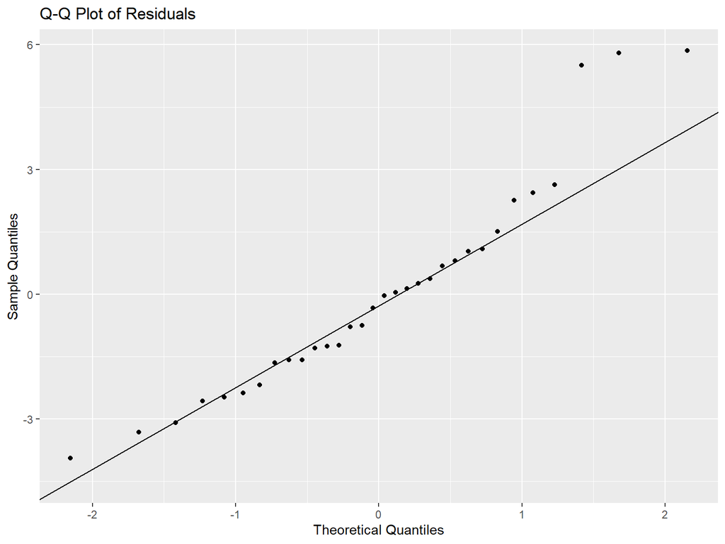

```r
ggplot(data = data.frame(residuals = residuals(model_mlr)), aes(sample = residuals)) +
  geom_qq() +
  geom_qq_line() +
  labs(title = "Q-Q Plot of Residuals",
       x = "Theoretical Quantiles",
       y = "Sample Quantiles")
```

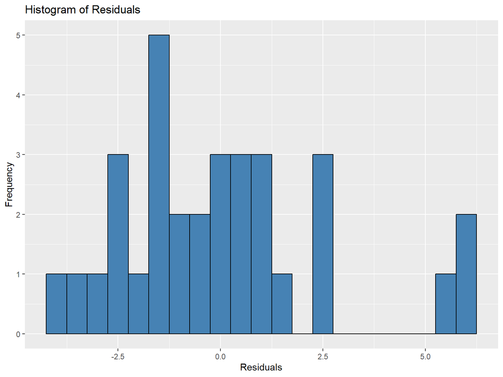

```r
ggplot(data = data.frame(residuals = residuals(model_mlr)), aes(x = residuals)) +
  geom_histogram(binwidth = 0.5, fill = "steelblue", color = "black") +
  labs(title = "Histogram of Residuals",
       x = "Residuals",
       y = "Frequency")
```

#### **Null and Alternative Hypotheses for Homoscedasticity:**

- H0: The residuals of the model have constant variance (homoscedasticity).
- H1: The residuals of the model do not have constant variance (heteroscedasticity).

```r
# Homoscedasticity test (Breusch-Pagan test)
library(lmtest)
bptest(model_mlr)
```

```
    studentized Breusch-Pagan test

data:  model_mlr
BP = 0.88072, df = 2, p-value = 0.6438
```

#### **Null and Alternative Hypotheses for Independence:**

- H0: The residuals of the model are independent (no autocorrelation).
- H1: The residuals of the model are not independent (autocorrelation present).

```r
# independence test (Durbin-Watson test)
dwtest(model_mlr)
```

```
    Durbin-Watson test

data:  model_mlr
DW = 1.3624, p-value = 0.02061
alternative hypothesis: true autocorrelation is greater than 0
```

## **MULTIPLE LINEAR REGRESSION MODEL**

### **US Macroeconomic Variables**

```r
library(ggplot2)
data("economics")
head(economics)
```

```
# A tibble: 6 × 6
  date         pce    pop psavert uempmed unemploy
  <date>     <dbl>  <dbl>   <dbl>   <dbl>    <dbl>
1 1967-07-01  507. 198712    12.6     4.5     2944
2 1967-08-01  510. 198911    12.6     4.7     2945
3 1967-09-01  516. 199113    11.9     4.6     2958
4 1967-10-01  512. 199311    12.9     4.9     3143
5 1967-11-01  517. 199498    12.8     4.7     3066
6 1967-12-01  525. 199657    11.8     4.8     3018
```

```r
tail(economics)
```

```
# A tibble: 6 × 6
  date          pce     pop psavert uempmed unemploy
  <date>      <dbl>   <dbl>   <dbl>   <dbl>    <dbl>
1 2014-11-01 12051. 319564.     7.3    13       9090
2 2014-12-01 12062  319746.     7.6    12.9     8717
3 2015-01-01 12046  319929.     7.7    13.2     8903
4 2015-02-01 12082. 320075.     7.9    12.9     8610
5 2015-03-01 12158. 320231.     7.4    12       8504
6 2015-04-01 12194. 320402.     7.6    11.5     8526
```

```r
?economics
```

### **US economic time series**

#### **Description**

This dataset was produced from US economic time series data available from https://fred.stlouisfed.org/. economics is in “wide” format, economics_long is in “long” format.

Usage economics

economics_long Format A data frame with 574 rows and 6 variables:

date Month of data collection

pce personal consumption expenditures, in billions of dollars, https://fred.stlouisfed.org/series/PCE

pop total population, in thousands, https://fred.stlouisfed.org/series/POP

psavert personal savings rate, https://fred.stlouisfed.org/series/PSAVERT/

uempmed median duration of unemployment, in weeks, https://fred.stlouisfed.org/series/UEMPMED

unemploy number of unemployed in thousands, https://fred.stlouisfed.org/series/UNEMPLOY

An object of class tbl_df (inherits from tbl, data.frame) with 2870 rows and 4 columns.

### **Estimate the Multiple Linear Regression Model**

```r
options(scipen = 999)
model_mlr <- lm(psavert ~ pce +
                  unemploy +
                  pop +
                  uempmed,
                data = economics)
summary(model_mlr)
```

```
Call:
lm(formula = psavert ~ pce + unemploy + pop + uempmed, data = economics)

Residuals:
    Min      1Q  Median      3Q     Max
-4.8282 -0.6982 -0.0981  0.6336  5.4816

Coefficients:
               Estimate  Std. Error t value             Pr(>|t|)
(Intercept) 45.67014927  2.23116237  20.469 < 0.0000000000000002 ***
pce          0.00085067  0.00011865   7.170     0.00000000000235 ***
unemploy     0.00024997  0.00004824   5.182     0.00000030589469 ***
pop         -0.00017334  0.00001101 -15.742 < 0.0000000000000002 ***
uempmed      0.16599616  0.03559460   4.664     0.00000387763733 ***
---
Signif. codes:  0 '***' 0.001 '**' 0.01 '*' 0.05 '.' 0.1 ' ' 1

Residual standard error: 1.186 on 569 degrees of freedom
Multiple R-squared:  0.8409,    Adjusted R-squared:  0.8398
F-statistic: 752.1 on 4 and 569 DF,  p-value: < 0.00000000000000022
```

### **Hypothesis Testing for Overall Model**

> Null hypothesis: The null model(intercept only model) is a better fit Alternative hypothesis: The full fitted model is a better fit

$$\hat{\text{Psavert}} = 45.67 +
0.00085(\text{pce}) +
0.00024(\text{umploy}) - 0.00017(\text{pop}) +
0.166(\text{uempmed})$$

### **Report the Results**

```r
library(report)
report(model_mlr)
```

```
We fitted a linear model (estimated using OLS) to predict psavert with pce,
unemploy, pop and uempmed (formula: psavert ~ pce + unemploy + pop + uempmed).
The model explains a statistically significant and substantial proportion of
variance (R2 = 0.84, F(4, 569) = 752.09, p < .001, adj. R2 = 0.84). The model's
intercept, corresponding to pce = 0, unemploy = 0, pop = 0 and uempmed = 0, is
at 45.67 (95% CI [41.29, 50.05], t(569) = 20.47, p < .001). Within this model:

  - The effect of pce is statistically significant and positive (beta = 8.51e-04,
95% CI [6.18e-04, 1.08e-03], t(569) = 7.17, p < .001; Std. beta = 1.02, 95% CI
[0.74, 1.30])
  - The effect of unemploy is statistically significant and positive (beta =
2.50e-04, 95% CI [1.55e-04, 3.45e-04], t(569) = 5.18, p < .001; Std. beta =
0.22, 95% CI [0.14, 0.31])
  - The effect of pop is statistically significant and negative (beta =
-1.73e-04, 95% CI [-1.95e-04, -1.52e-04], t(569) = -15.74, p < .001; Std. beta
= -2.15, 95% CI [-2.41, -1.88])
  - The effect of uempmed is statistically significant and positive (beta = 0.17,
95% CI [0.10, 0.24], t(569) = 4.66, p < .001; Std. beta = 0.23, 95% CI [0.13,
0.33])

Standardized parameters were obtained by fitting the model on a standardized
version of the dataset. 95% Confidence Intervals (CIs) and p-values were
computed using a Wald t-distribution approximation.
```

### **Marginal Effect of the Linear Effect**

```r
model_mlr2 <- lm(log(psavert) ~ log(pce) +
                  log(unemploy) +
                  log(pop) +
                  log(uempmed),
                data = economics)
summary(model_mlr2)
```

```
Call:
lm(formula = log(psavert) ~ log(pce) + log(unemploy) + log(pop) +
    log(uempmed), data = economics)

Residuals:
     Min       1Q   Median       3Q      Max
-0.84206 -0.08004  0.00405  0.09707  0.66780

Coefficients:
              Estimate Std. Error t value       Pr(>|t|)
(Intercept)   11.01128    6.79493   1.621         0.1057
log(pce)      -0.36115    0.08416  -4.291 0.000020862402 ***
log(unemploy)  0.40892    0.06486   6.305 0.000000000579 ***
log(pop)      -0.80126    0.57188  -1.401         0.1617
log(uempmed)   0.16186    0.06612   2.448         0.0147 *
---
Signif. codes:  0 '***' 0.001 '**' 0.01 '*' 0.05 '.' 0.1 ' ' 1

Residual standard error: 0.1702 on 569 degrees of freedom
Multiple R-squared:  0.8019,    Adjusted R-squared:  0.8005
F-statistic: 575.9 on 4 and 569 DF,  p-value: < 0.00000000000000022
```

### **Model Diagnostics**

```r
model_new <- lm(log(psavert) ~ log(pce) +
                  log(unemploy) +
                  log(uempmed),
                data = economics)
summary(model_new)
```

```
Call:
lm(formula = log(psavert) ~ log(pce) + log(unemploy) + log(uempmed),
    data = economics)

Residuals:
     Min       1Q   Median       3Q      Max
-0.84235 -0.08221  0.00680  0.10284  0.66225

Coefficients:
              Estimate Std. Error t value             Pr(>|t|)
(Intercept)    1.49863    0.27449   5.460         0.0000000713 ***
log(pce)      -0.47809    0.01082 -44.167 < 0.0000000000000002 ***
log(unemploy)  0.48189    0.03870  12.453 < 0.0000000000000002 ***
log(uempmed)   0.08387    0.03572   2.348               0.0192 *
---
Signif. codes:  0 '***' 0.001 '**' 0.01 '*' 0.05 '.' 0.1 ' ' 1

Residual standard error: 0.1704 on 570 degrees of freedom
Multiple R-squared:  0.8012,    Adjusted R-squared:  0.8002
F-statistic: 765.9 on 3 and 570 DF,  p-value: < 0.00000000000000022
```

### **Normality Test for the Residuals**

> Null hypothesis: The residuals follows a normal distribution Alternative hypothesis: The residuals deviates from a normal distribution

```r
resid <- residuals(model_new)
shap_test <- shapiro.test(resid)
shap_test
```

```
    Shapiro-Wilk normality test

data:  resid
W = 0.96791, p-value = 0.0000000006994
```

```r
resid_df <- data.frame(Residuals = resid)
head(resid_df,5)
```

```
    Residuals
1  0.03733909
2  0.03644449
3 -0.01562424
4  0.02736958
5  0.03986434
```

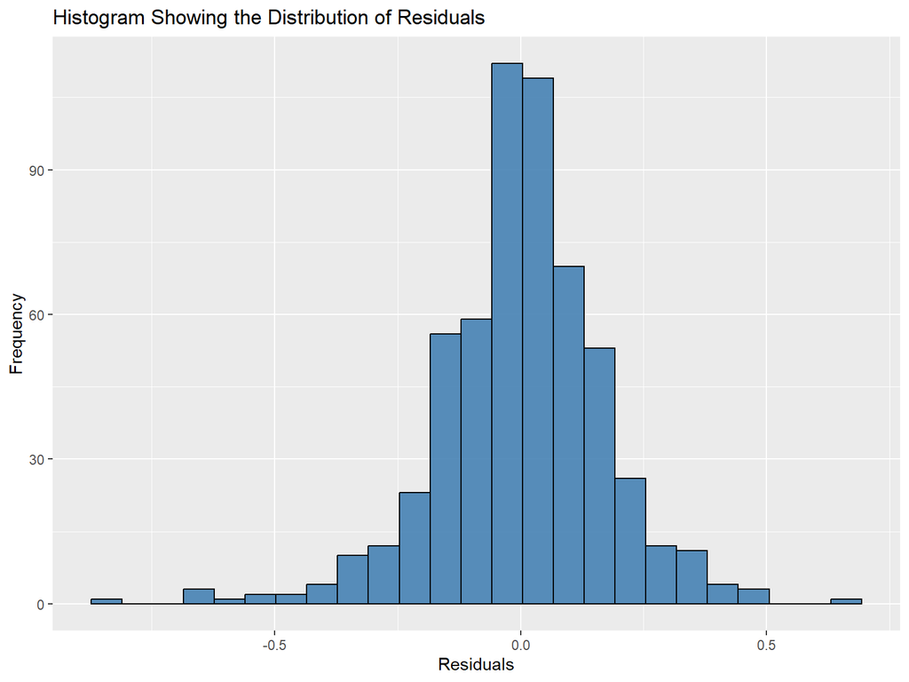

```r
ggplot(data = resid_df, aes(x = Residuals))+
  geom_histogram(fill = "steelblue",
                 color = "black",
                 bins = 25,
                 alpha = 0.9)+
  labs(
    title = "Histogram Showing the Distribution of Residuals",
    x = "Residuals",
    y = "Frequency"
  )
```

### **Heteroscedasticity**

> Null: Residuals have a constant variance over time Alternative: The variance of the residuals is not constant over time

```r
# Homoscedasticity test (Breusch-Pagan test)
library(lmtest)
bptest(model_new)
```

```
    studentized Breusch-Pagan test

data:  model_new
BP = 67.261, df = 3, p-value = 0.00000000000001646
```

### **Multicollinearity**

```r
library(car)
vif(model_new)
```

```
     log(pce) log(unemploy)  log(uempmed)
     2.066333      3.802894      3.772870
```

## **Additional Example: Macroeconomic Variables**

```r
df = read.csv("training model.csv")
head(df, 10)
```

```
   year       CPI ExchRate LendIntRates
1  1987  7.872727 16.45499     14.00000
2  1988  8.848083 17.74710     15.00000
3  1989 10.035029 20.57247     17.25000
4  1990 11.602322 22.91477     18.75000
5  1991 13.805882 27.50870     18.99750
6  1992 17.579356 32.21683     21.06750
7  1993 25.662147 58.00133     29.98917
8  1994 33.056538 56.05058     36.24000
9  1995 33.570345 51.42930     28.79583
10 1996 36.546050 57.11487     33.78667
```

### **Convert year variable to actual date format**

```r
df$year <- as.Date(df$year)
head(df,10)
```

```
         year       CPI ExchRate LendIntRates
1  1975-06-11  7.872727 16.45499     14.00000
2  1975-06-12  8.848083 17.74710     15.00000
3  1975-06-13 10.035029 20.57247     17.25000
4  1975-06-14 11.602322 22.91477     18.75000
5  1975-06-15 13.805882 27.50870     18.99750
6  1975-06-16 17.579356 32.21683     21.06750
7  1975-06-17 25.662147 58.00133     29.98917
8  1975-06-18 33.056538 56.05058     36.24000
9  1975-06-19 33.570345 51.42930     28.79583
10 1975-06-20 36.546050 57.11487     33.78667
```

### **Run the Multiple Linear Model**

```r
model <- lm(CPI ~ ExchRate+LendIntRates, data = df)
summary(model)
```

```
Call:
lm(formula = CPI ~ ExchRate + LendIntRates, data = df)

Residuals:
    Min      1Q  Median      3Q     Max
-26.417 -11.680   1.241   6.814  46.891

Coefficients:
             Estimate Std. Error t value     Pr(>|t|)
(Intercept)    7.8998    15.0231   0.526      0.60403
ExchRate       1.2664     0.1581   8.011 0.0000000419 ***
LendIntRates  -1.4861     0.5103  -2.912      0.00785 **
---
Signif. codes:  0 '***' 0.001 '**' 0.01 '*' 0.05 '.' 0.1 ' ' 1

Residual standard error: 17.84 on 23 degrees of freedom
Multiple R-squared:  0.7721,    Adjusted R-squared:  0.7523
F-statistic: 38.96 on 2 and 23 DF,  p-value: 0.0000000411
```

```r
library(report)
report_statistics(model)
```

```
beta = 7.90, 95% CI [-23.18, 38.98], t(23) = 0.53, p = 0.604; Std. beta = 1.08e-16, 95% CI [-0.20, 0.20]
beta = 1.27, 95% CI [0.94, 1.59], t(23) = 8.01, p < .001; Std. beta = 0.80, 95% CI [0.59, 1.01]
beta = -1.49, 95% CI [-2.54, -0.43], t(23) = -2.91, p = 0.008; Std. beta = -0.29, 95% CI [-0.50, -0.08]
```

```r
report(model)
```

```
We fitted a linear model (estimated using OLS) to predict CPI with ExchRate and
LendIntRates (formula: CPI ~ ExchRate + LendIntRates). The model explains a
statistically significant and substantial proportion of variance (R2 = 0.77,
F(2, 23) = 38.96, p < .001, adj. R2 = 0.75). The model's intercept,
corresponding to ExchRate = 0 and LendIntRates = 0, is at 7.90 (95% CI [-23.18,
38.98], t(23) = 0.53, p = 0.604). Within this model:

  - The effect of ExchRate is statistically significant and positive (beta =
1.27, 95% CI [0.94, 1.59], t(23) = 8.01, p < .001; Std. beta = 0.80, 95% CI
[0.59, 1.01])
  - The effect of LendIntRates is statistically significant and negative (beta =
-1.49, 95% CI [-2.54, -0.43], t(23) = -2.91, p = 0.008; Std. beta = -0.29, 95%
CI [-0.50, -0.08])

Standardized parameters were obtained by fitting the model on a standardized
version of the dataset. 95% Confidence Intervals (CIs) and p-values were
computed using a Wald t-distribution approximation.
```

## **Model Diagnostics for the MLR Model**

> Multicollinearity

Multicollinearity occurs when two or more predictor variables in a multiple regression model are highly correlated with each other. This can lead to unstable estimates of the regression coefficients and make it difficult to determine the individual effect of each predictor on the outcome variable.

```r
library (car)
# Calculate VIF
vif(model)
```

```
    ExchRate LendIntRates
    1.009553     1.009553
```

### **Diagnostic Plots for the MLR Model**

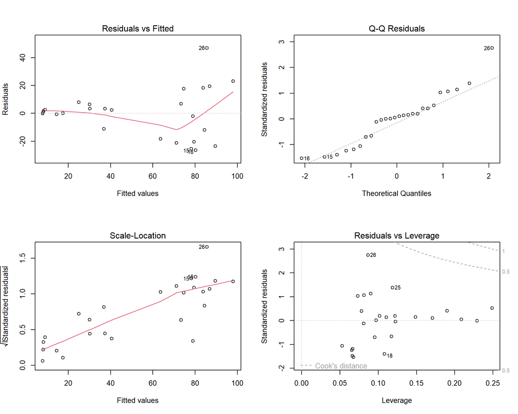

```r
# Generate diagnostic plots
par(mfrow =c(2 ,2))
plot(model)
```

```r
par(mfrow =c(1 ,1))
```

### **Identify the Influential Observation as Indicared by Cook’s Distance**

```r
# Calculate Cook's distance
cooks_distance <- cooks.distance(model)
# Identify influential observations
influential_obs <- which(cooks_distance > (4 / nrow(df)))
influential_obs
```

```
26
26
```

### **Remove Influential Observation and Refit the Model**

```r
# Remove influential observation
df_no_influential <- df[-influential_obs, ]
# Refit the model without influential observation
model_mlr_no_influential <- lm(CPI ~ ExchRate+LendIntRates, data = df_no_influential)
summary(model_mlr_no_influential)
```

```
Call:
lm(formula = CPI ~ ExchRate + LendIntRates, data = df_no_influential)

Residuals:
    Min      1Q  Median      3Q     Max
-22.570  -9.177  -0.247   8.439  27.958

Coefficients:
             Estimate Std. Error t value     Pr(>|t|)
(Intercept)   12.1604    12.6506   0.961      0.34687
ExchRate       1.1668     0.1359   8.589 0.0000000178 ***
LendIntRates  -1.5004     0.4275  -3.510      0.00198 **
---
Signif. codes:  0 '***' 0.001 '**' 0.01 '*' 0.05 '.' 0.1 ' ' 1

Residual standard error: 14.94 on 22 degrees of freedom
Multiple R-squared:  0.8084,    Adjusted R-squared:  0.791
F-statistic: 46.41 on 2 and 22 DF,  p-value: 0.00000001278
```

### **Inferential Test for Normality and Homoscedasticity**

#### **Null and Alternative Hypotheses for Normality:**

- H0: The residuals of the model are normally distributed.
- H1: The residuals of the model are not normally distributed.

```r
# Normality test (Shapiro-Wilk test)
shapiro.test(residuals(model_mlr))
```

```
    Shapiro-Wilk normality test

data:  residuals(model_mlr)
W = 0.98603, p-value = 0.00002631
```

```r
# Normality test (Anderson-Darling test)
library(nortest)
ad.test(residuals(model_mlr))
```

```
    Anderson-Darling normality test

data:  residuals(model_mlr)
A = 1.9611, p-value = 0.00005299
```

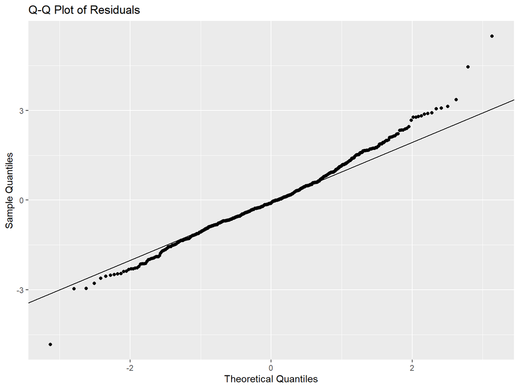

```r
ggplot(data = data.frame(residuals = residuals(model_mlr)), aes(sample = residuals)) +
  geom_qq() +
  geom_qq_line() +
  labs(title = "Q-Q Plot of Residuals",
       x = "Theoretical Quantiles",
       y = "Sample Quantiles")
```

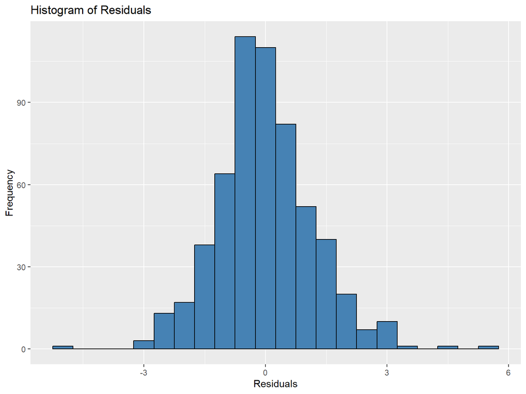

```r
ggplot(data = data.frame(residuals = residuals(model_mlr)), aes(x = residuals)) +
  geom_histogram(binwidth = 0.5, fill = "steelblue", color = "black") +
  labs(title = "Histogram of Residuals",
       x = "Residuals",
       y = "Frequency")
```

#### **Null and Alternative Hypotheses for Homoscedasticity:**

- H0: The residuals of the model have constant variance (homoscedasticity).
- H1: The residuals of the model do not have constant variance (heteroscedasticity).

```r
# Homoscedasticity test (Breusch-Pagan test)
library(lmtest)
bptest(model_mlr)
```

```
    studentized Breusch-Pagan test

data:  model_mlr
BP = 50.022, df = 4, p-value = 0.0000000003573
```

#### **Null and Alternative Hypotheses for Independence:**

- H0: The residuals of the model are independent (no autocorrelation).
- H1: The residuals of the model are not independent (autocorrelation present).

```r
# independence test (Durbin-Watson test)
dwtest(model_mlr)
```

```
    Durbin-Watson test

data:  model_mlr
DW = 0.4103, p-value < 0.00000000000000022
alternative hypothesis: true autocorrelation is greater than 0
```

## **Marginal Elasticities**

```r
model_elasticity <- lm(log(CPI) ~ log(ExchRate) + log(LendIntRates), data = df)
summary(model_elasticity)
```

```
Call:
lm(formula = log(CPI) ~ log(ExchRate) + log(LendIntRates), data = df)

Residuals:
    Min      1Q  Median      3Q     Max
-0.3328 -0.1943  0.0154  0.1211  0.5152

Coefficients:
                  Estimate Std. Error t value            Pr(>|t|)
(Intercept)       -0.70426    0.52767  -1.335            0.195053
log(ExchRate)      1.51494    0.08531  17.758 0.00000000000000635 ***
log(LendIntRates) -0.55204    0.13754  -4.014            0.000544 ***
---
Signif. codes:  0 '***' 0.001 '**' 0.01 '*' 0.05 '.' 0.1 ' ' 1

Residual standard error: 0.223 on 23 degrees of freedom
Multiple R-squared:  0.9348,    Adjusted R-squared:  0.9291
F-statistic: 164.8 on 2 and 23 DF,  p-value: 0.00000000000002317
```

### **The estimated equation is:**

$$\ln(\text{CPI})=-0.7043+1.5149\ln(\text{ExchRate})-0.5520\ln(\text{LendIntRates}).$$

Because **both the dependent and independent variables are in logarithms**, this is a **log-log (double-log) regression model**. The coefficients are interpreted as **elasticities**, **not multipliers**.

or equivalently,

$$CPI=e^{-0.7043}\times
ExchRate^{1.5149}\times LendIntRates^{-0.5520}.$$

## **Interpretation of the coefficients**

### **1. Exchange Rate Elasticity**

The coefficient is

$$\beta_1=1.5149.$$

Interpretation:

Holding lending interest rates constant, a **1% increase in the exchange rate** is associated with approximately a **1.515% increase in the Consumer Price Index (CPI)**.

Since

$$1.515>1,$$

CPI is **elastic** with respect to the exchange rate.

This suggests that exchange rate depreciation has a more-than-proportional effect on inflation.

### **2. Lending Interest Rate Elasticity**

The coefficient is

$$\beta_2=-0.5520.$$

Interpretation:

Holding exchange rates constant, a **1% increase in lending interest rates** is associated with approximately a **0.552% decrease in CPI**.

This relationship is **inelastic** because

$$|{-0.552}|<1.$$

Economically, higher lending rates reduce borrowing and aggregate demand, thereby lowering inflationary pressures.

## **Statistical significance**

### Exchange Rate

$$p<0.001$$

Highly significant.

There is very strong evidence that exchange rate movements affect CPI.

### **Lending Interest Rate**

$$p=0.000544$$

Also highly significant.

Higher lending rates significantly reduce inflation.

### **Goodness of fit**

#### **Multiple (R^2)**

$$R^2=0.9348$$

#### **Interpretation:**

Approximately **93.48%** of the variation in CPI is explained jointly by exchange rates and lending interest rates.

#### **Adjusted (R^2)**

$$0.9291$$

Since it is very close to (R^2), the model is not overfitting.

### **Overall model significance**

The F-statistic is

$$F=164.8$$

with

$$p=2.317\times10^{-14}.$$

#### **Interpretation:**

The model is highly statistically significant, indicating that the explanatory variables jointly provide substantial explanatory power for CPI.

#### **What can you compute from this model?**

Unlike a consumption model, **you cannot compute the Keynesian multiplier**

$$k=\frac{1}{1-MPC},$$

because:

- there is **no consumption variable**,
- there is **no income variable**, and
- the coefficients are **elasticities**, not marginal propensities to consume.

Instead, you obtain:

- Exchange rate elasticity of inflation = **1.515**
- Lending interest rate elasticity of inflation = **−0.552**
- Overall explanatory power ((R^2))
- Statistical significance of each determinant
- Predictive equation for CPI
- Evidence on exchange rate pass-through and the effect of monetary policy (through lending rates)

#### **A suitable interpretation for a research paper**

The estimated double-log regression model indicates that the exchange rate has a positive and statistically significant effect on inflation. Specifically, a 1% increase in the exchange rate is associated with an estimated 1.515% increase in the Consumer Price Index (CPI), holding lending interest rates constant. This suggests a highly elastic exchange rate pass-through to domestic prices. Conversely, lending interest rates have a negative and statistically significant effect on inflation, with a 1% increase in lending rates associated with an estimated 0.552% decrease in CPI. The model explains approximately 93.5% of the variation in CPI ((R^2 = 0.9348)), and the overall regression is highly significant ((F = 164.8), (p < 0.001)), indicating that exchange rates and lending interest rates jointly provide a strong explanation of inflation dynamics in the sample.

## **Demand Analysis**

```r
data <- read.csv("demand_data.csv")
head(data)
```

```
   Quantity     Price   Income SubPrice CompPrice
1 1984478.1 11.450930 55999.34 13.58089  8.492027
2 1710573.8 17.459662 39969.41 24.43538  3.066009
3 1286243.7 12.907723 49316.78 19.02049  8.453461
4 1291620.1 18.596209 77268.43 17.72545  8.105735
5  731467.2 19.285607 48974.14 16.03860  7.410923
6 3635345.6  8.546678 73421.01 23.20370  6.366376
```

### **Estimate the Linear Model**

```r
model <- lm(log(Quantity) ~
              log(Price) +
              log(Income) +
              log(SubPrice) +
              log(CompPrice),
            data=data)

summary(model)
```

```
Call:
lm(formula = log(Quantity) ~ log(Price) + log(Income) + log(SubPrice) +
    log(CompPrice), data = data)

Residuals:
     Min       1Q   Median       3Q      Max
-0.30128 -0.10557 -0.01491  0.08426  0.34314

Coefficients:
               Estimate Std. Error t value             Pr(>|t|)
(Intercept)     8.19405    0.54655  14.992 < 0.0000000000000002 ***
log(Price)     -1.13896    0.05620 -20.265 < 0.0000000000000002 ***
log(Income)     0.75306    0.04321  17.428 < 0.0000000000000002 ***
log(SubPrice)   0.53673    0.05375   9.986 < 0.0000000000000002 ***
log(CompPrice) -0.40680    0.04222  -9.635 0.000000000000000993 ***
---
Signif. codes:  0 '***' 0.001 '**' 0.01 '*' 0.05 '.' 0.1 ' ' 1

Residual standard error: 0.1407 on 95 degrees of freedom
Multiple R-squared:  0.9104,    Adjusted R-squared:  0.9066
F-statistic: 241.3 on 4 and 95 DF,  p-value: < 0.00000000000000022
```

These are excellent results for illustrating **demand elasticity**. Since you estimated a **double-log demand model**, every slope coefficient is an elasticity. This makes the model ideal for teaching and reporting economic concepts.

Your estimated model is

$$\ln(Q)=8.194-1.139\ln(P)+0.753\ln(Y)+0.537\ln(P_s)-0.407\ln(P_c)$$

where:

### **1. Price Elasticity of Demand**

The estimated own-price elasticity is

$$E_p=-1.139.$$

### **Interpretation**

Holding income, substitute prices, and complementary goods’ prices constant, a **1% increase in the price of the good decreases quantity demanded by approximately 1.139%**.

Since

$$|E_p|=1.139>1,$$

the demand is **price elastic**. Consumers are relatively responsive to price changes.

### **Economic implication**

A price increase is likely to reduce total revenue because the percentage decline in quantity demanded exceeds the percentage increase in price.

### **2. Income Elasticity of Demand**

The estimated income elasticity is

$$E_Y=0.753.$$

### **Interpretation**

Holding other variables constant, a **1% increase in consumer income increases quantity demanded by approximately 0.753%**.

Since

$$0<E_Y<1,$$

the product is a **normal necessity**.

### **Economic implication**

Demand increases as consumers become wealthier, but at a slower rate than income growth.

### **3. Cross-Price Elasticity (Substitute Goods)**

The estimated elasticity is

$$E_{Sub}=0.537.$$

### **Interpretation**

A **1% increase in the price of a substitute good increases demand for this product by approximately 0.537%**, holding other variables constant.

Because

$$E_{Sub}>0,$$

the goods are **substitutes**.

### **Examples**

- Coca-Cola and Pepsi
- Tea and Coffee
- Butter and Margarine

### **Economic implication**

If competitors raise their prices, consumers switch to your product.

### **4. Cross-Price Elasticity (Complementary Goods)**

The estimated elasticity is

$$E_{Comp}=-0.407.$$

### **Interpretation**

A **1% increase in the price of a complementary good decreases demand for this product by approximately 0.407%**, holding other factors constant.

Because

$$E_{Comp}<0,$$

the goods are **complements**.

### **Examples**

- Cars and fuel
- Printers and ink cartridges
- Bread and butter

### **Economic implication**

An increase in the price of a complementary product reduces demand for the focal product.

#### **5. Statistical Significance**

All explanatory variables have p-values less than 0.001, indicating that price, income, substitute prices, and complementary goods’ prices all have statistically significant effects on quantity demanded.

### **6. Model Fit**

The coefficient of determination is

$$R^2=0.9104.$$

### **Interpretation**

Approximately **91.04%** of the variation in quantity demanded is explained by the four explanatory variables.

The adjusted (R^2) of 0.9066 indicates that the model retains very strong explanatory power after accounting for the number of predictors.

### **7. Overall Model Significance**

The overall regression is highly significant:

- (F = 241.3)
- (p < 0.001)

This indicates that the explanatory variables jointly provide substantial explanatory power for explaining demand.

### **Summary Table**

| Variable | Elasticity | Economic Interpretation | Classification |
| --- | --- | --- | --- |
| Price | **−1.139** | 1% ↑ in price → 1.139% ↓ in demand | **Elastic demand** |
| Income | **0.753** | 1% ↑ in income → 0.753% ↑ in demand | **Normal necessity** |
| Substitute Price | **0.537** | 1% ↑ in substitute’s price → 0.537% ↑ in demand | **Substitute goods** |
| Complement Price | **−0.407** | 1% ↑ in complement’s price → 0.407% ↓ in demand | **Complementary goods** |

The model demonstrates several fundamental concepts in demand analysis within a single regression:

- ✅ Demand function estimation
- ✅ Own-price elasticity of demand
- ✅ Income elasticity of demand
- ✅ Cross-price elasticity of demand (substitutes)
- ✅ Cross-price elasticity of demand (complements)
- ✅ Elastic vs. inelastic demand
- ✅ Normal vs. inferior goods (if income elasticity were negative)
- ✅ Statistical significance (t-tests and p-values)
- ✅ Overall model significance (F-test)
- ✅ Goodness of fit ((R^2) and Adjusted (R^2))

Because it captures nearly all of the core elasticity concepts in one framework, this type of double-log demand model is widely used in econometrics and is an excellent example for classroom demonstrations, assignments, and applied research.

## **Consumption and Income Example**

```r
df2 <- read.csv("income.csv")
head(df2, 10)
```

```
   Year Income Consumption
1  1950  791.8       733.2
2  1951  819.0       748.7
3  1952  844.3       771.4
4  1953  880.0       802.5
5  1954  894.0       822.7
6  1955  944.5       873.8
7  1956  989.4       899.8
8  1957 1012.1       919.7
9  1958 1028.8       932.9
10 1959 1067.2       979.4
```

## **Simple Linear Model**

### **Estimate the Impact of Income on Consumption**

```r
model2 <- lm(Consumption ~ Income, data = df2)
summary(model2)
```

```
Call:
lm(formula = Consumption ~ Income, data = df2)

Residuals:
    Min      1Q  Median      3Q     Max
-43.242  -3.039   1.581   8.497  47.318

Coefficients:
             Estimate Std. Error t value            Pr(>|t|)
(Intercept) 11.373746   9.629463   1.181               0.246
Income       0.898329   0.005848 153.603 <0.0000000000000002 ***
---
Signif. codes:  0 '***' 0.001 '**' 0.01 '*' 0.05 '.' 0.1 ' ' 1

Residual standard error: 18.82 on 34 degrees of freedom
  (1 observation deleted due to missingness)
Multiple R-squared:  0.9986,    Adjusted R-squared:  0.9985
F-statistic: 2.359e+04 on 1 and 34 DF,  p-value: < 0.00000000000000022
```

### **Hypothesis for the Overall Significance of the Model (F-test)**

> Null hypothesis: The null model is better than the fitted model (the model does not explain a significant portion of the variance in consumption).

> Alternative hypothesis: The fitted model is better than the null model (the model explains a significant portion of the variance in consumption).

```r
library(report)
report(model2)
```

```
We fitted a linear model (estimated using OLS) to predict Consumption with
Income (formula: Consumption ~ Income). The model explains a statistically
significant and substantial proportion of variance (R2 = 1.00, F(1, 34) =
23593.84, p < .001, adj. R2 = 1.00). The model's intercept, corresponding to
Income = 0, is at 11.37 (95% CI [-8.20, 30.94], t(34) = 1.18, p = 0.246).
Within this model:

  - The effect of Income is statistically significant and positive (beta = 0.90,
95% CI [0.89, 0.91], t(34) = 153.60, p < .001; Std. beta = 1.00, 95% CI [0.99,
1.01])

Standardized parameters were obtained by fitting the model on a standardized
version of the dataset. 95% Confidence Intervals (CIs) and p-values were
computed using a Wald t-distribution approximation.
```

### **Estimate the Long-run Consumption Model**

```r
model3 <- lm(Consumption ~ Income-1, data = df2)
summary(model3)
```

```
Call:
lm(formula = Consumption ~ Income - 1, data = df2)

Residuals:
    Min      1Q  Median      3Q     Max
-44.384  -3.548   4.125  11.033  42.305

Coefficients:
       Estimate Std. Error t value            Pr(>|t|)
Income 0.904860   0.001916   472.3 <0.0000000000000002 ***
---
Signif. codes:  0 '***' 0.001 '**' 0.01 '*' 0.05 '.' 0.1 ' ' 1

Residual standard error: 18.93 on 35 degrees of freedom
  (1 observation deleted due to missingness)
Multiple R-squared:  0.9998,    Adjusted R-squared:  0.9998
F-statistic: 2.231e+05 on 1 and 35 DF,  p-value: < 0.00000000000000022
```